# HW2-EDA with R - Part1: Plotting

### Problem 5 - How do regions of the country compare?

In county_df you’ll see that there’s a Region field. Create a set of faceted histograms showing how some variable of interest to you compares by region. For example, you could explore how the regions compare with respect to the distribution of MeanCommute time. Make sure your graph has a title and good axis labels.

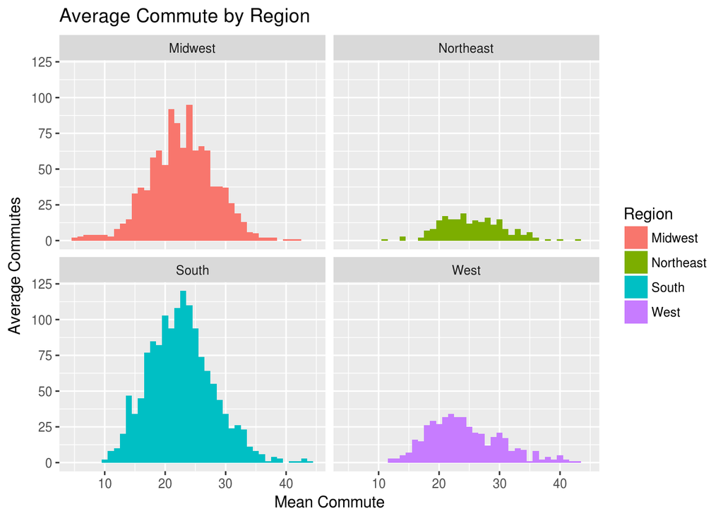

```r
ggplot(county_df,aes(x=county_df$MeanCommute, fill = Region)) + geom_histogram(binwidth=1) + labs(x= "Mean Commute") + facet_wrap(~Region) + ggtitle("Average Commute by Region") + ylab("Average Commutes")
```

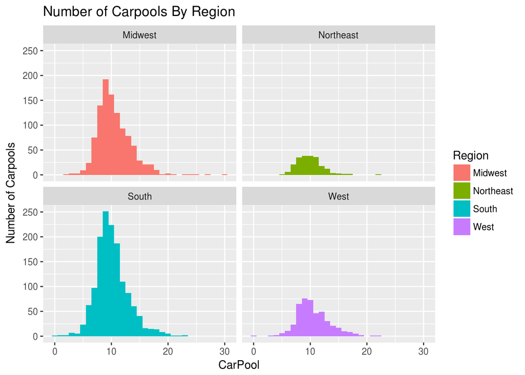

```r
ggplot(county_df,aes(x=county_df$Carpool, fill = Region)) + geom_histogram(binwidth=1) + labs(x= "CarPool") + facet_wrap(~Region) +
ggtitle("Number of Carpools By Region")+ ylab("Number of Carpools")
```

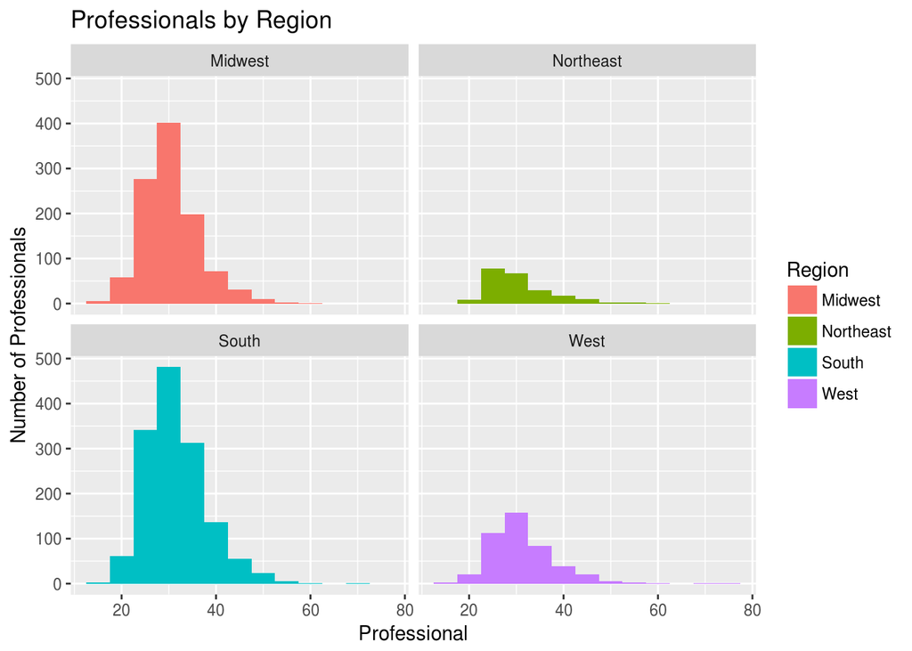

```r
ggplot(county_df,aes(x=county_df$Professional, fill = Region)) + geom_histogram(binwidth=5) + labs(x= "Professional") + facet_wrap(~Region) +ggtitle("Professionals by Region") + ylab("Number of Professionals")
```

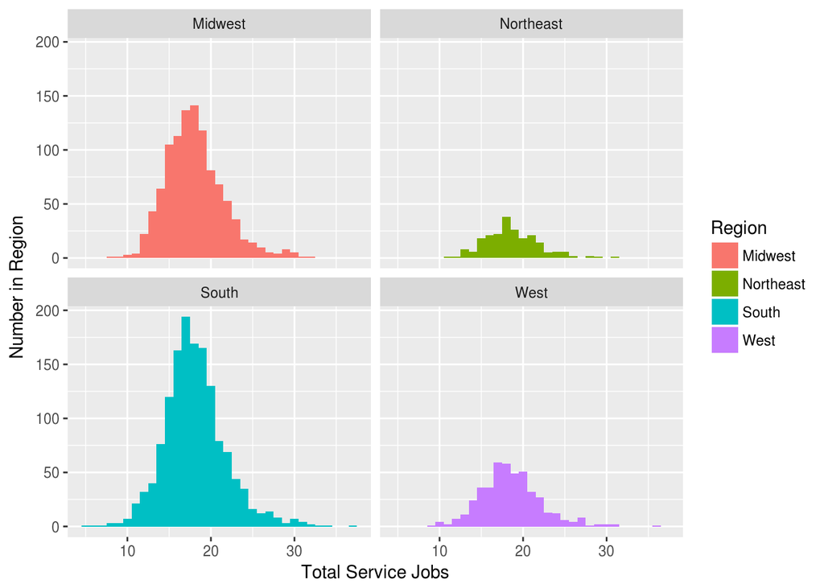

```r
ggplot(county_df,aes(x=county_df$Service, fill = Region)) + geom_histogram(binwidth=1) + labs(x= "Service") + facet_wrap(~Region) + ylab("Number in Region") + xlab ("Total Service Jobs")
```

### Problem 6 - Basic bar chart

Create a bar chart showing the number of counties by Region in the US. Make sure your graph has a title and good axis labels.

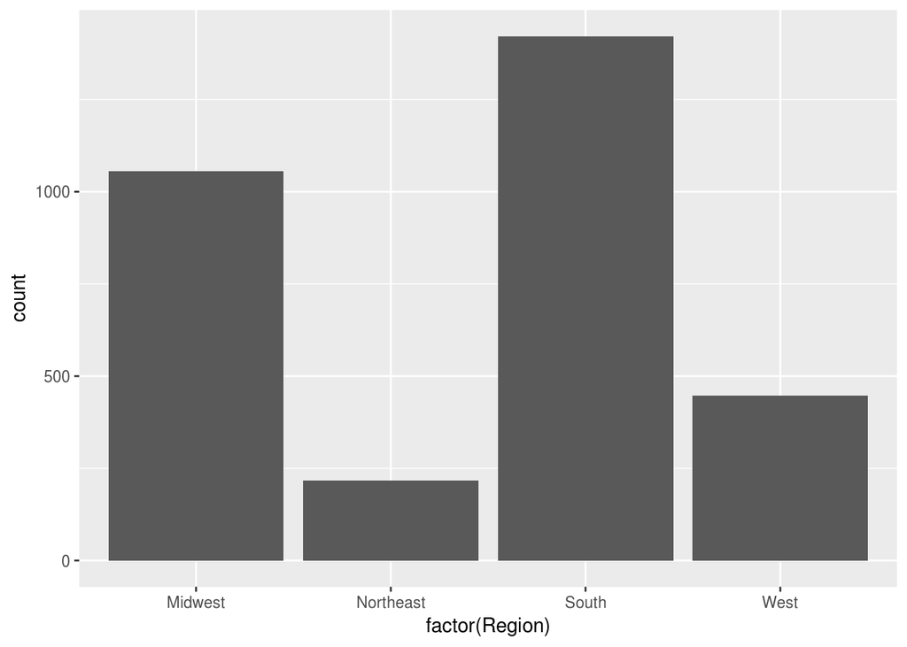

```r
ggplot(county_df, aes(x=factor(Region))) + geom_bar(stat = "count")
```

### Problem 7 - Basic scatter plots

Create a scatter plot using the Michigan only data frame comparing Income and MeanCommute.

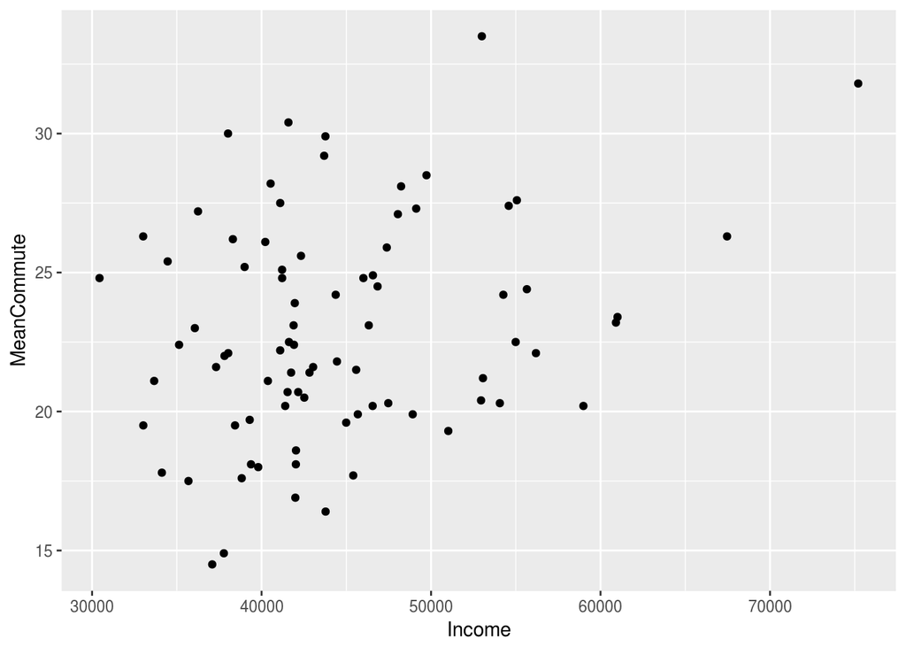

```r
ggplot(county_MI,aes(x=Income,y=MeanCommute)) + geom_point()
```

Create a modified version of the above scatter plot in which the point color is mapped to peninsula.

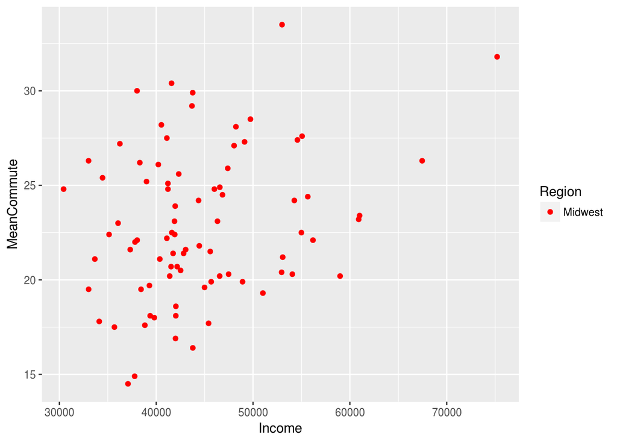

```r
ggplot(county_MI,aes(x=Income,y=MeanCommute,fill= Region)) + geom_point(color = "red")
```

Your thoughts on the relationship between these variables?

Now, create a few more scatter plots using variables of your choosing in which you facet by peninsula as well. How do the relationships compare across the peninsulas?

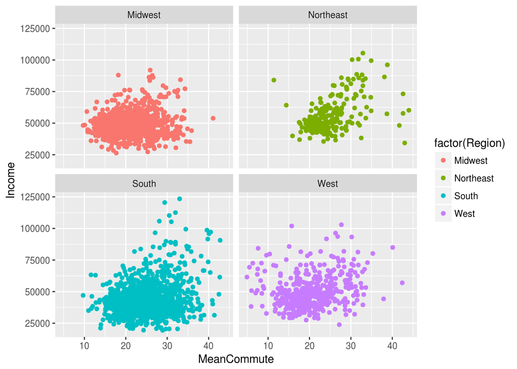

```r
ggplot(county_df,aes(y=Income,x=MeanCommute)) + geom_point(aes(colour = factor(Region))) + facet_wrap(~Region)
```

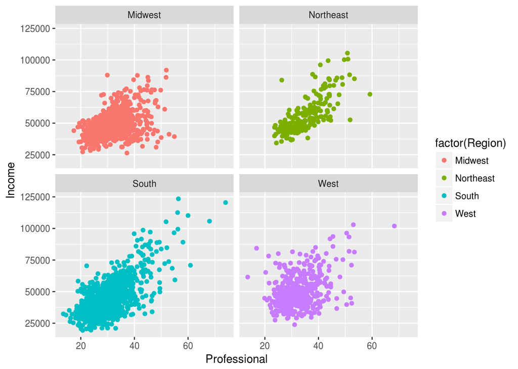

```r
ggplot(county_df,aes(y=Income,x=Professional)) + geom_point(aes(colour = factor(Region))) + facet_wrap(~Region)
```

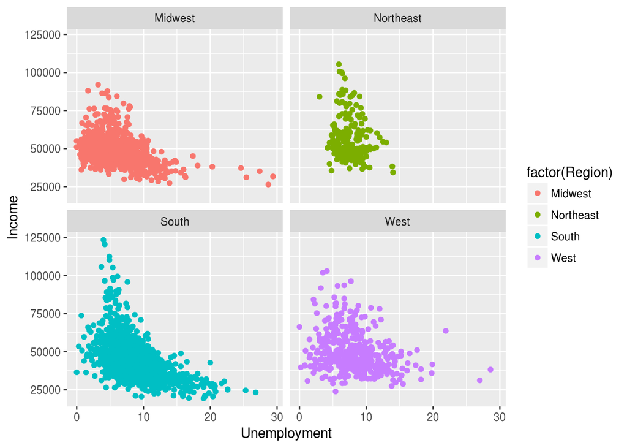

```r
ggplot(county_df,aes(y=Income,x=Unemployment)) + geom_point(aes(colour = factor(Region))) + facet_wrap(~Region)
```